# Praca domowa 2

Wiktoria Grodzka

## Dane

Dane wykorzystane w Pracy domowej 2 są związane z kampaniami marketingu bezpośredniego portugalskiej instytucji bankowej. Kampanie marketingowe opierały się na rozmowach telefonicznych. Często wymagany był więcej niż jeden kontakt z tym samym klientem, aby uzyskać dostęp do tego, czy produkt (lokata bankowa) zostanie (lub nie) subskrybowany. Opis wszystkich kolumn znajduje się również w pliku `README.md`.

#### Dane klienta banku

| Zmienna | Opis |
| --- | --- |
| **age** | wiek |
| **job** : admin., unknown, unemployed, management, housemaid, entrepreneur, student, blue-collar, self-employed, retired, technician, services | administrator, nieznany, bezrobotny, kierownictwo, pokojówka, przedsiębiorca, student, pracownik fizyczny, samozatrudniony, emeryt, technik, usługi |
| **marital** : married, divorced, single; note: divorced means divorced or widowed) | żonaty/zamężna, rozwiedzion_, kawaler/panna; uwaga: rozwiedzion_ oznacza rozwiedzion_ lub owdowiał_ |
| **education** : unknown, secondary, primary, tertiary | nieznane, średnie, podstawowe, wyższe |
| **default** : yes, no | czy kredyt jest niespłacany : tak, nie |
| **balance** : average yearly balance, in euros | średnie roczne saldo w euro |
| **housing** : has housing loan? yes, no | czy posiada kredyt mieszkaniowy? tak, nie |
| **loan** : has personal loan? yes, no | ma pożyczkę osobistą? tak, nie |

#### Dane związane z ostatnim kontaktem w bieżącej kampanii

| Zmienna | Opis |
| --- | --- |
| **contact** : unknown, telephone, cellular | nieznany, telefon, komórkowy |
| **day** : last contact day of the month | dzień miesiąca ostatniego kontaktu |
| **month** : last contact month of year, jan, feb, mar, …, nov, dec | miesiąc ostatniego kontaktu w roku, styczeń, luty, marzec, …, listopad, grudzień |
| **duration** : last contact duration, in seconds | czas trwania ostatniego kontaktu w sekundach |

## Zadanie 1

Weźmy pod uwagę zawody (`job`) klientów banku. Który zawód zacząco wyróżnia się w posiadaniu kredytu mieszkaniowego lub pożyczki osobistej?

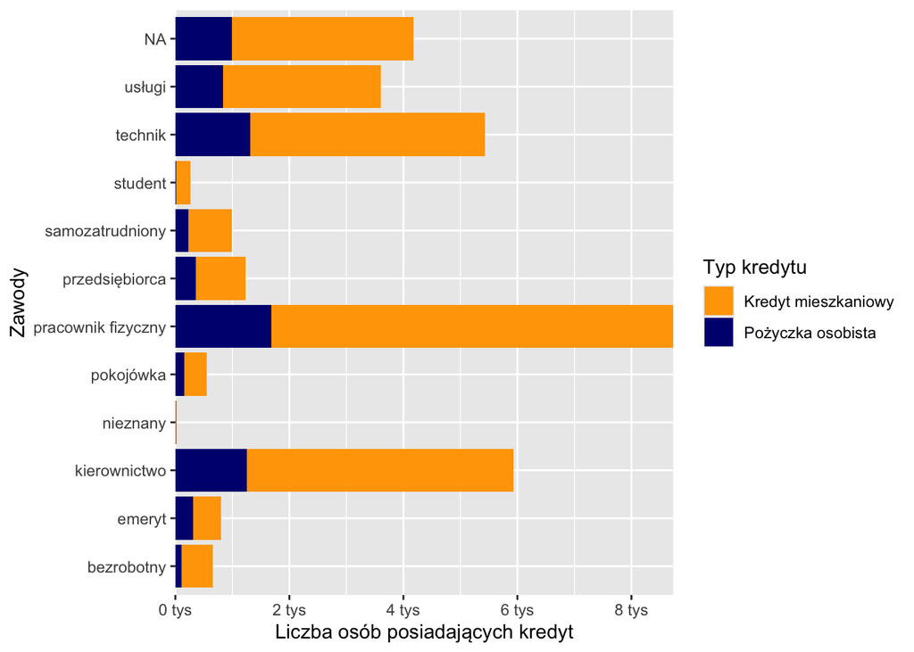

```r
#----------------------------liczba osób w danym zawodzie z kredytem
df %>%
  group_by(job) %>%
  mutate(loan=ifelse(loan=='yes',1,0), housing=ifelse(housing=='yes',1,0), job=case_when(
    job=="admin"~"administrator",
    job=="unknown"~"nieznany",
    job=="unemployed"~"bezrobotny",
    job=="management"~"kierownictwo",
    job=="housemaid"~"pokojówka",
    job=="entrepreneur"~"przedsiębiorca",
    job=="student"~"student",
    job=="blue-collar"~"pracownik fizyczny",
    job=="self-employed"~"samozatrudniony",
    job=="retired"~"emeryt",
    job=="technician"~"technik",
    job=="services"~"usługi"
  )) %>%
  summarise(count_h=sum(housing),count_l=sum(loan)) %>%
  pivot_longer(cols = c(count_h, count_l), names_to = "type", values_to = "count") %>%
  ggplot(aes(x=count, y=job, fill=type)) +
  geom_col(position="stack") +
  scale_fill_manual(values = c("count_l"="navyblue", "count_h"="orange"), labels=c("count_l"="Pożyczka osobista", "count_h"="Kredyt mieszkaniowy")) +   scale_x_continuous(expand=c(0,0), labels = label_number(scale = 0.001, suffix=" tys"))+ labs(
    x="Liczba osób posiadających kredyt",
    y="Zawody",
    fill="Typ kredytu"
  )
```

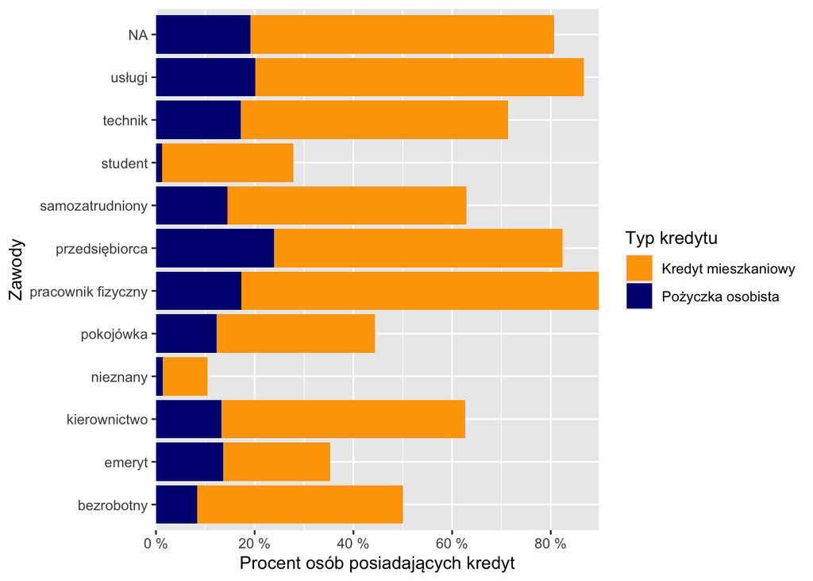

```r
#----------------------------procent osób w danym zawodzie z kredytem
df %>%
  group_by(job) %>%
  mutate(loan=ifelse(loan=='yes',1,0), housing=ifelse(housing=='yes',1,0),job=case_when(
    job=="admin"~"administrator",
    job=="unknown"~"nieznany",
    job=="unemployed"~"bezrobotny",
    job=="management"~"kierownictwo",
    job=="housemaid"~"pokojówka",
    job=="entrepreneur"~"przedsiębiorca",
    job=="student"~"student",
    job=="blue-collar"~"pracownik fizyczny",
    job=="self-employed"~"samozatrudniony",
    job=="retired"~"emeryt",
    job=="technician"~"technik",
    job=="services"~"usługi"
  )) %>%
  summarise(count_h=sum(housing),count_l=sum(loan),number=n()) %>%
  mutate(pr_h=count_h/number,pr_l=count_l/number) %>%
  select(job,pr_h,pr_l) %>%
  pivot_longer(cols = c(pr_h, pr_l), names_to = "type", values_to = "procent") %>%
  ggplot(aes(x=procent, y=job, fill=type)) +
  geom_col(position="stack") +
  scale_fill_manual(values = c("pr_l"="navyblue", "pr_h"="orange"), labels=c("pr_l"="Pożyczka osobista", "pr_h"="Kredyt mieszkaniowy")) +   scale_x_continuous(expand=c(0,0), labels = label_number(scale = 100, suffix=" %"))+ labs(
    x="Procent osób posiadających kredyt",
    y="Zawody",
    fill="Typ kredytu")
```

**Komentarz:** Widzimy, że kredyt jest najbardziej popularny wśród pracowników fizycznych oraz, że w każdym zawodzie częściej wybierany jest kredyt mieszkaniowy niż pożyczka osobista. Sądzę, że w tym przypadku istotniejszy jest wykres przedstawiający procent osób posiadających kredyt w danym zawodzie, ponieważ dobrze obrazuje różnice w trendach ze względu na zawód.

## Zadanie 2

Wybierając klientów, którzy mają nieznany sposób kontaktu (`contact`). Jak rozkłada się ich wiek w podziale na status związku?

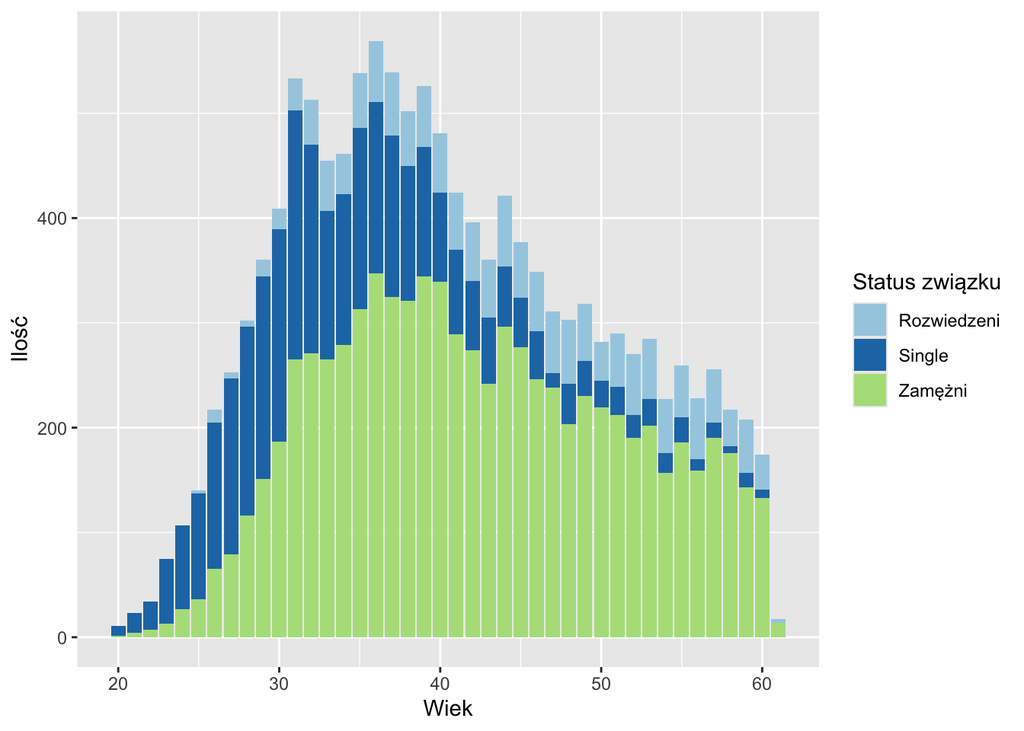

```r
df %>% filter(contact=="unknown") %>% mutate(marital=case_when(
  marital=="married"~"Zamężni",
  marital=="single"~"Single",
  marital=="divorced"~"Rozwiedzeni"
)) %>%
  group_by(age, marital) %>% summarise(count=n()) %>%
  ggplot(aes(x=age, y=count, fill=marital)) +
  geom_col() + labs(
    x="Wiek",
    y="Ilość",
    fill="Status związku"
  ) + scale_fill_brewer(palette="Paired")
```

**Komentarz:** Dzięki złożeniu ze sobą osób o różnym statusie związku możemy zauważyć jak duży udział mają poszczególne grupy statusowe w danym wieku.

## Zadanie 3

Jaka jest różnica pomiędzy średnim rocznym saldem w euro w zależności od wykształcenia i tego czy kredyt jest niespłacany?

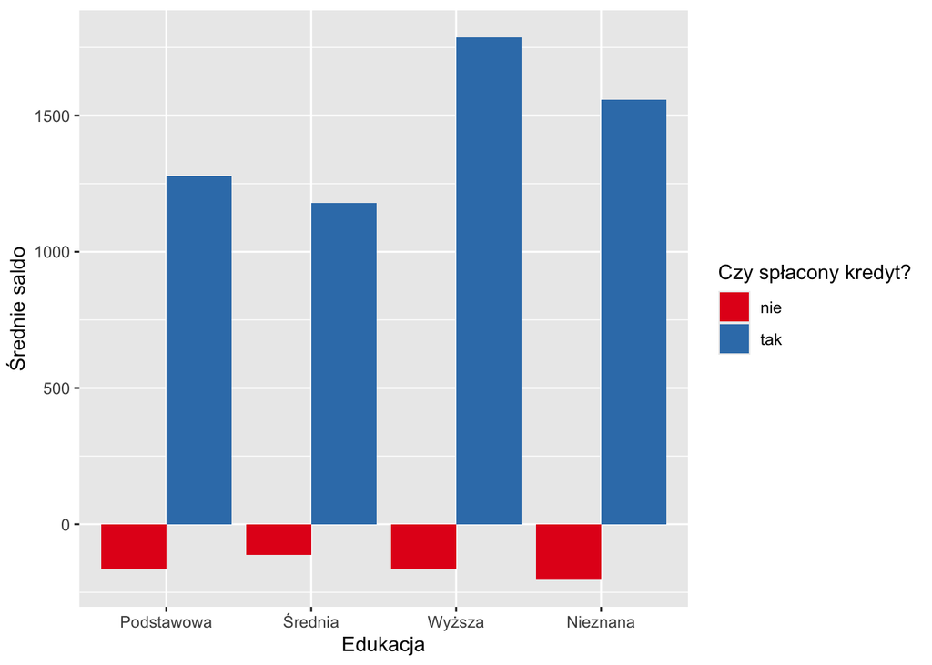

```r
df %>%
  group_by(education, default) %>%
  summarise(mean=mean(balance)) %>%
  mutate(default=ifelse(default=="yes", "nie","tak"))%>% ggplot(aes(x=education, y=mean,fill=default)) + geom_bar(stat="identity",position = "dodge")+ labs(
    x="Edukacja",
    y="Średnie saldo",
    fill="Czy spłacony kredyt?"
  ) + scale_fill_brewer(palette="Set1") + scale_x_discrete( labels=c("primary" = "Podstawowa",
                              "secondary" = "Średnia",
                              "tertiary" = "Wyższa",
                              "unknown"="Nieznana"))
```

**Komentarz:** Jak mogliśmy się spodziewać, gdy kredyt jest niespłacony to średnie saldo jest na minusie. Dodatkowo najwyższe średnie roczne saldo wśród osób ze spłaconym kredytem występuje w grupie o wyższej edukacji, a najniższe średnie roczne saldo dla osób o niespłaconym kredycie występuje wśród grupy o nieznanej edukacji.

## Zadanie 4

Czy dzień i miesiąc kontaktu z klientem ma wpływ na średni czas trwania rozmowy w stosunku do średniego czasu trwania rozmowy?

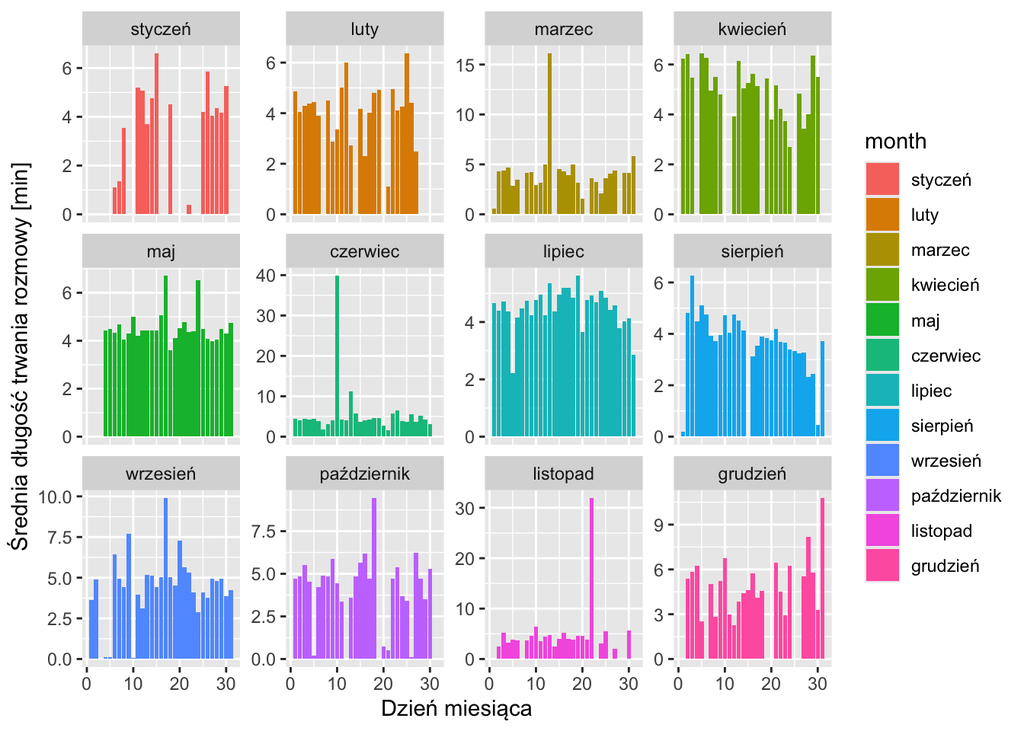

```r
#------------------------------średni czas trwania rozmowy każdego dnia roku
df %>%
  select(day, month,duration) %>%
  mutate(month=case_when(
    month=="jan"~"styczeń",
    month=="feb"~"luty",
    month=="mar"~"marzec",
    month=="apr"~"kwiecień",
    month=="may"~"maj",
    month=="jun"~"czerwiec",
    month=="jul"~"lipiec",
    month=="aug"~"sierpień",
    month=="oct"~"wrzesień",
    month=="sep"~"październik",
    month=="nov"~"listopad",
    month=="dec"~"grudzień"
  ),month = factor(month, levels = c("styczeń", "luty", "marzec", "kwiecień", "maj", "czerwiec",
                  "lipiec", "sierpień", "wrzesień", "październik", "listopad", "grudzień"))) %>%
  group_by(month, day) %>% summarise(mean=mean(duration)/60) %>%
  ggplot(aes(x=day,y=mean,fill=month))+geom_col()+ labs(x="Dzień miesiąca",y="Średnia długość trwania rozmowy [min]") + facet_wrap(~month,scales="free_y")
```

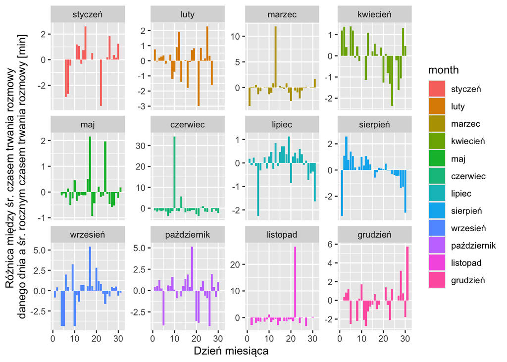

```r
#----różnica między średnim rocznym czasem trwania rozmowy, a średnim czasem trwania rozmowy każdego dnia roku
df %>%
  select(day, month,duration) %>%
  mutate(month=case_when(
    month=="jan"~"styczeń",
    month=="feb"~"luty",
    month=="mar"~"marzec",
    month=="apr"~"kwiecień",
    month=="may"~"maj",
    month=="jun"~"czerwiec",
    month=="jul"~"lipiec",
    month=="aug"~"sierpień",
    month=="oct"~"wrzesień",
    month=="sep"~"październik",
    month=="nov"~"listopad",
    month=="dec"~"grudzień"
  ),month = factor(month, levels = c("styczeń", "luty", "marzec", "kwiecień", "maj", "czerwiec",
                  "lipiec", "sierpień", "wrzesień", "październik", "listopad", "grudzień"))) %>%
  group_by(month, day) %>% summarise(śr=mean(duration)/60) %>%
  mutate(delta=śr-mean(śr)) %>%
  ggplot(aes(x=day,y=delta,fill=month))+geom_col()+ labs(x="Dzień miesiąca",y="Różnica między śr. czasem trwania rozmowy \ndanego dnia a śr. rocznym czasem trwania rozmowy [min]") + facet_wrap(~month,scales="free_y")
```

```r
#czcionka nazwy osi, albo enter
```

## Zadanie 5

Czy jest zależnośc pomiędzy wiekiem klientów a ich średnim rocznym saldzie w euro w podziale na stopień wykształcenia?

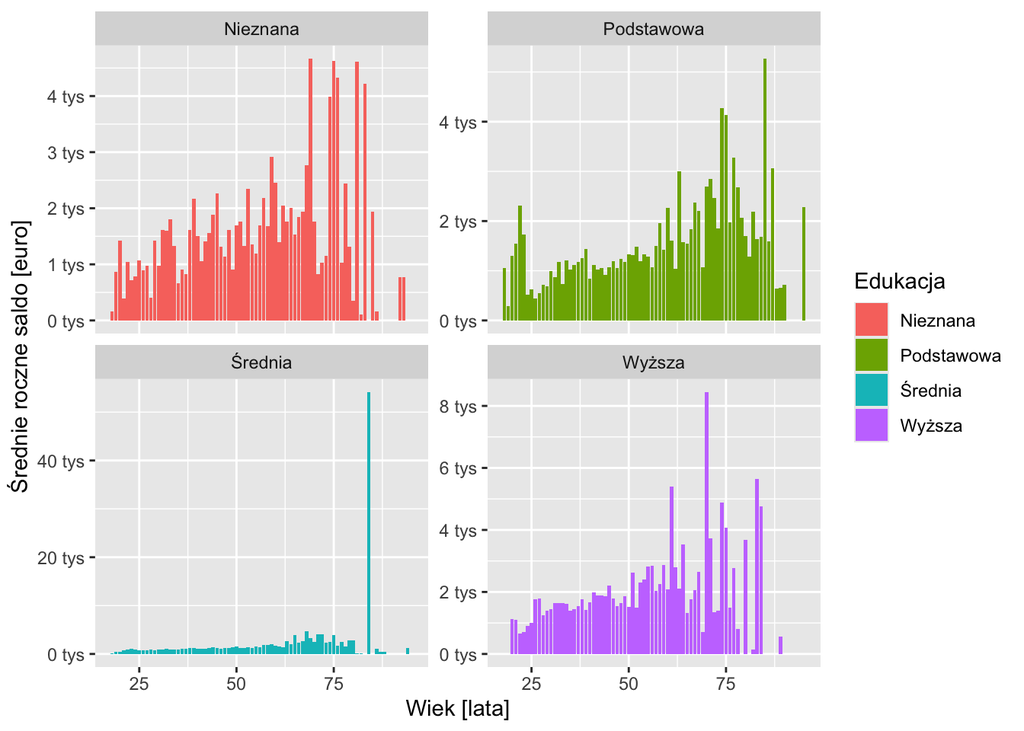

```r
df1<-df %>%
  group_by(education, age) %>% mutate(education=case_when(
    education=="primary" ~ "Podstawowa",
                              education=="secondary" ~ "Średnia",
                              education=="tertiary" ~ "Wyższa",
                              education=="unknown"~"Nieznana")) %>% summarise(mean=mean(balance))
p_col<-ggplot(df1,aes(x=age, y=mean, fill=education)) +
  geom_col()+labs(
    x="Wiek [lata]",
    y="Średnie roczne saldo [euro]",
    fill="Edukacja"
  )
p_col + facet_wrap(~education,scales="free_y")+ scale_y_continuous(labels = label_number(scale = 0.001, suffix=" tys"))
```

**Komentarz:** Dzięki free_y wykresy są czytelniejsze, niestety outliery przeszkadzają w interpretacji wykresów.

## Zadanie 6

Rozważmy osoby, które są bezrobotne albo ich zawód jest nieznany. Czy procent osób, które są bezrobotne i nie spłacają kredytu jest większy od procenta osób o nieznanym zawodzie i nie spłacanym kredycie? Jaki typ kredytu jest (przez te osoby) najczęściej niespłacany?

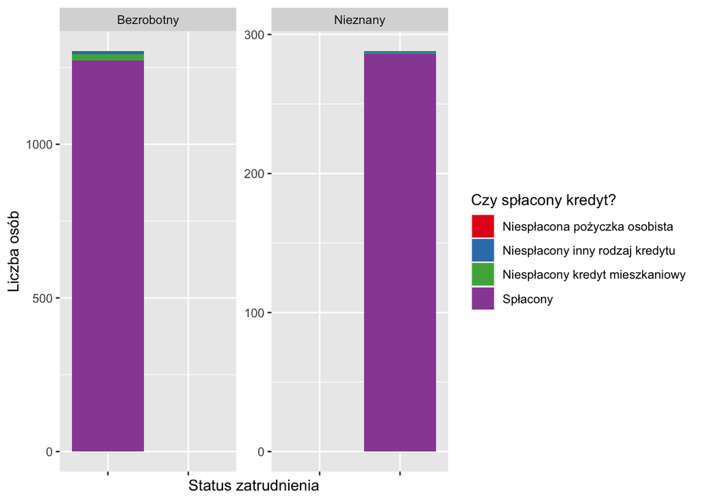

```r
df %>%
  filter(job=="unknown" | job=="unemployed") %>%
  mutate(job=ifelse(job=="unknown", "Nieznany","Bezrobotny"),default=case_when(
    default=="no"~"Spłacony",
    default=="yes" & housing=="yes"~"Niespłacony kredyt mieszkaniowy",
    default=="yes" & loan=="yes"~"Niespłacona pożyczka osobista",
    TRUE~"Niespłacony inny rodzaj kredytu"
    )) %>%
  group_by(job, default) %>%
  summarise(count=n()) %>%
  ggplot(aes(x=job, y=count,fill=default)) + geom_col()+
  scale_fill_brewer(palette="Set1") + facet_wrap(~job, scales="free_y") +labs(
    x="Status zatrudnienia", y="Liczba osób",fill="Czy spłacony kredyt?") + theme(axis.text.x = element_blank())
```